# The Big Mac Index: Purchasing Power Parity & Currency Valuation

## 2. Data Loading & Validation

| Column | Description |
| --- | --- |
| `dollar_price` | Local Big Mac price converted to USD at market exchange rate |
| `USD_raw` | Raw PPP implied over/undervaluation vs USD (0 = fairly valued) |
| `USD_adjusted` | GDP-adjusted valuation — accounts for lower labor costs in poorer countries |
| `local_price` | Price in domestic currency |
| `dollar_ex` | Market exchange rate (local per USD) at time of survey |

```python
df = pd.read_csv('big_mac.csv')
df['date'] = pd.to_datetime(df['date'])
df = df.sort_values('date').reset_index(drop=True)

# Attach region
df['region'] = df['name'].map(REGION_MAP).fillna('Other')

print(f'Rows: {len(df):,}')
print(f'Countries: {df["name"].nunique()}')
print(f'Date range: {df["date"].min().date()}  →  {df["date"].max().date()}')
print(f'Survey dates: {df["date"].nunique()}')
print()
print('Missing values:')
key_cols = ['dollar_price','USD_raw','USD_adjusted','local_price','dollar_ex']
print(df[key_cols].isna().sum().to_string())
print()
df[key_cols].describe().round(3)
```

```
Rows: 1,386
Countries: 57
Date range: 2000-04-01  →  2020-07-01
Survey dates: 33

Missing values:
dollar_price      0
USD_raw           0
USD_adjusted    684
local_price       0
dollar_ex         0
```

|  | dollar_price | USD_raw | USD_adjusted | local_price | dollar_ex |
| --- | --- | --- | --- | --- | --- |
| count | 1386.000 | 1386.000 | 702.000 | 1386.000 | 1386.000 |
| mean | 3.255 | -0.231 | -0.020 | 10043.233 | 3817.912 |
| std | 1.261 | 0.298 | 0.256 | 181450.811 | 69296.091 |
| min | 0.640 | -0.779 | -0.578 | 1.050 | 0.302 |
| 25% | 2.335 | -0.446 | -0.185 | 7.250 | 2.982 |
| 50% | 3.044 | -0.291 | -0.032 | 24.250 | 7.751 |
| 75% | 4.013 | -0.067 | 0.097 | 119.000 | 47.092 |
| max | 8.312 | 1.273 | 1.485 | 4000000.000 | 1600500.000 |

## 3. Exploratory Overview

### 3.1 Global Price Snapshot — Most Recent Survey

The horizontal bar chart below ranks every country by their most recent Big Mac price in USD. The red line marks the US price — countries to the right have a more expensive Big Mac (and, by PPP logic, a stronger-than-implied currency), while countries to the left are cheaper relative to the dollar.

This is the cleanest single-frame summary of global purchasing power disparities.

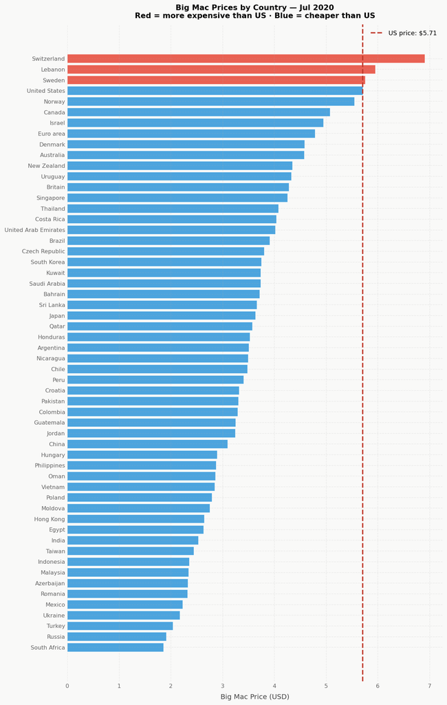

```
Most expensive: Switzerland  $6.91
Least expensive: South Africa  $1.86
Countries more expensive than US: 3 of 56
```

```python
latest_date = df['date'].max()
latest = df[df['date'] == latest_date].dropna(subset=['dollar_price']).copy()
latest = latest.sort_values('dollar_price')

us_price = latest[latest['name'] == 'United States']['dollar_price'].values
us_price = us_price[0] if len(us_price) > 0 else None

fig, ax = plt.subplots(figsize=(10, max(8, len(latest) * 0.28)), facecolor=PALETTE['bg'])

colors = ['#E74C3C' if p > (us_price or 0) else '#3498DB' for p in latest['dollar_price']]
bars = ax.barh(latest['name'], latest['dollar_price'],
               color=colors, edgecolor='white', linewidth=0.4, alpha=0.88)

if us_price:
    ax.axvline(us_price, color=PALETTE['us'], linewidth=2, linestyle='--',
               label=f'US price: ${us_price:.2f}')
    ax.legend(frameon=False, fontsize=10)

ax.set_xlabel('Big Mac Price (USD)', labelpad=8)
ax.set_title(f'Big Mac Prices by Country — {latest_date.strftime("%b %Y")}\n'
             f'Red = more expensive than US · Blue = cheaper than US',
             fontsize=12, pad=10)
ax.tick_params(length=0, labelsize=9)
plt.tight_layout()
plt.show()

print(f'Most expensive: {latest.iloc[-1]["name"]}  ${latest.iloc[-1]["dollar_price"]:.2f}')
print(f'Least expensive: {latest.iloc[0]["name"]}  ${latest.iloc[0]["dollar_price"]:.2f}')
if us_price:
    pct_above = (latest['dollar_price'] > us_price).sum()
    print(f'Countries more expensive than US: {pct_above} of {len(latest)}')
```

### 3.2 US Big Mac Price Over Time

The US price series is the anchor for this dataset — it defines what a "fairly valued" currency implies in dollar terms. The trend line here also provides the basis for the forecast in Section 7.

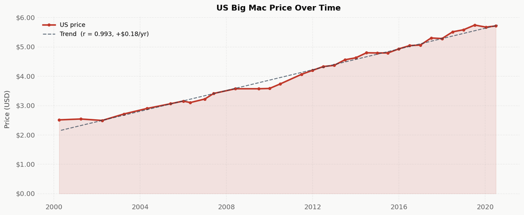

```
Price in 2000:  $2.51
Price in 2020:  $5.71
Total increase:    127.5%
CAGR:              4.14% per year
Linear trend:      +$0.177 per year  (r = 0.993)
```

```python
us = df[df['name'] == 'United States'].dropna(subset=['dollar_price']).copy()
us['years_since_2000'] = us['date'].dt.year + us['date'].dt.month/12 - 2000

fig, ax = plt.subplots(figsize=(12, 5), facecolor=PALETTE['bg'])

ax.fill_between(us['date'], us['dollar_price'], alpha=0.12, color=PALETTE['primary'])
ax.plot(us['date'], us['dollar_price'],
        color=PALETTE['primary'], linewidth=2.5, marker='o', markersize=4, label='US price')

# Fit and plot trend line
slope, intercept, r, p, se = stats.linregress(us['years_since_2000'], us['dollar_price'])
x_fit = np.linspace(us['years_since_2000'].min(), us['years_since_2000'].max(), 200)
dates_fit = pd.to_datetime('2000-01-01') + pd.to_timedelta(x_fit * 365.25, unit='D')
ax.plot(dates_fit, slope * x_fit + intercept,
        color=PALETTE['secondary'], linewidth=1.5, linestyle='--', alpha=0.7,
        label=f'Trend  (r = {r:.3f}, +${slope:.2f}/yr)')

ax.yaxis.set_major_formatter(mticker.FormatStrFormatter('$%.2f'))
ax.legend(frameon=False, fontsize=10)
style_ax(ax, 'US Big Mac Price Over Time', '', 'Price (USD)')
plt.tight_layout()
plt.show()

start_price = us.iloc[0]['dollar_price']
end_price   = us.iloc[-1]['dollar_price']
years_span  = (us.iloc[-1]['date'] - us.iloc[0]['date']).days / 365.25
cagr = (end_price / start_price) ** (1 / years_span) - 1

print(f'Price in {us.iloc[0]["date"].year}:  ${start_price:.2f}')
print(f'Price in {us.iloc[-1]["date"].year}:  ${end_price:.2f}')
print(f'Total increase:    {(end_price/start_price - 1)*100:.1f}%')
print(f'CAGR:              {cagr*100:.2f}% per year')
print(f'Linear trend:      +${slope:.3f} per year  (r = {r:.3f})')
```

### 3.3 All-Country Price Trajectories

The spaghetti chart shows every country's dollar-price series simultaneously. The US is highlighted in red. The spread of the bundle over time is informative: **widening spread** means global purchasing power disparities are growing; **convergence** would suggest exchange rates are adjusting toward PPP.

Individual country lines are deliberately unlabeled — the point here is the aggregate shape of the distribution, not any single country's path. Selected countries are examined in detail in later sections.

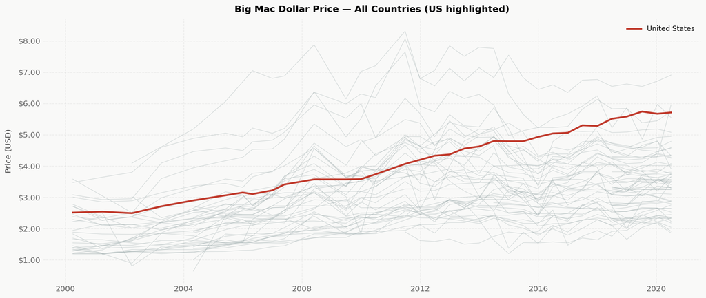

```python
fig, ax = plt.subplots(figsize=(14, 6), facecolor=PALETTE['bg'])

for name, group in df.groupby('name'):
    g = group.dropna(subset=['dollar_price'])
    if name == 'United States':
        continue
    ax.plot(g['date'], g['dollar_price'],
            color=PALETTE['neutral'], linewidth=0.8, alpha=0.35)

# US on top
us_g = df[df['name'] == 'United States'].dropna(subset=['dollar_price'])
ax.plot(us_g['date'], us_g['dollar_price'],
        color=PALETTE['primary'], linewidth=2.5, label='United States', zorder=5)

ax.yaxis.set_major_formatter(mticker.FormatStrFormatter('$%.2f'))
ax.legend(frameon=False, fontsize=10)
style_ax(ax, 'Big Mac Dollar Price — All Countries (US highlighted)',
         '', 'Price (USD)')
plt.tight_layout()
plt.show()
```

## 4. Currency Valuation Analysis

The core use case of the Big Mac Index is as a PPP gauge. `USD_raw` encodes the raw implied valuation:

- **Positive** → currency is **overvalued** vs the dollar (Big Mac costs more than in the US)
- **Negative** → currency is **undervalued** vs the dollar (Big Mac costs less than in the US)
- **Zero** → currency is at PPP parity

This section looks at both the most recent snapshot and how valuation has evolved over time for selected currencies.

### 4.1 Most Over/Undervalued Currencies — Raw PPP (Most Recent)

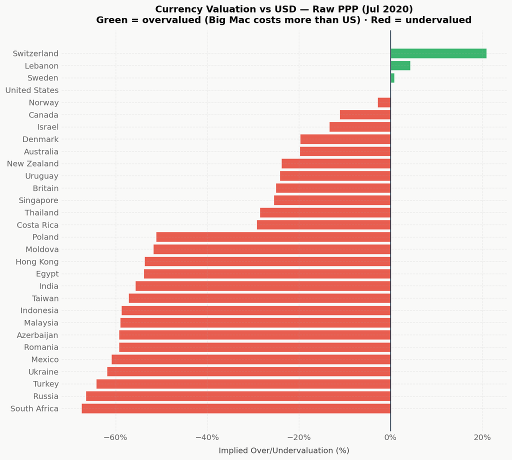

```
Most overvalued:  Switzerland                +20.9%
Most undervalued: South Africa               -67.4%
```

```python
val_latest = df[df['date'] == latest_date].dropna(subset=['USD_raw']).copy()
# Exclude euro area aggregate to avoid double-counting
val_latest = val_latest[val_latest['name'] != 'Euro area']

top_over  = val_latest.nlargest(15, 'USD_raw')
top_under = val_latest.nsmallest(15, 'USD_raw')
combined  = pd.concat([top_under, top_over]).sort_values('USD_raw')

fig, ax = plt.subplots(figsize=(10, 9), facecolor=PALETTE['bg'])
colors = [PALETTE['positive'] if v > 0 else PALETTE['negative']
          for v in combined['USD_raw']]
bars = ax.barh(combined['name'], combined['USD_raw'] * 100,
               color=colors, edgecolor='white', linewidth=0.4, alpha=0.9)
ax.axvline(0, color=PALETTE['secondary'], linewidth=1.2)
ax.xaxis.set_major_formatter(mticker.PercentFormatter())
style_ax(ax,
         f'Currency Valuation vs USD — Raw PPP ({latest_date.strftime("%b %Y")})\n'
         f'Green = overvalued (Big Mac costs more than US) · Red = undervalued',
         'Implied Over/Undervaluation (%)', '')
ax.tick_params(length=0)
plt.tight_layout()
plt.show()

most_over  = combined.iloc[-1]
most_under = combined.iloc[0]
print(f'Most overvalued:  {most_over["name"]:25s}  {most_over["USD_raw"]*100:+.1f}%')
print(f'Most undervalued: {most_under["name"]:25s}  {most_under["USD_raw"]*100:+.1f}%')
```

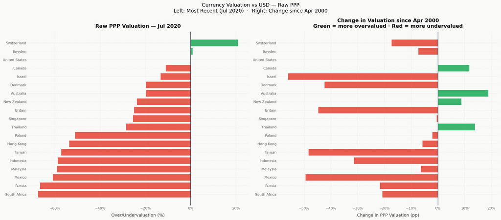

```
Currencies most improved (less undervalued / more overvalued) since 2000-04-01:
         name  USD_raw_early  USD_raw  valuation_change
    Australia         -0.386   -0.198             0.188
     Thailand         -0.423   -0.286             0.138
       Canada         -0.228   -0.111             0.117
  New Zealand         -0.326   -0.238             0.088
United States          0.000    0.000             0.000

Currencies most deteriorated since 2000-04-01:
   name  USD_raw_early  USD_raw  valuation_change
 Israel          0.426   -0.134            -0.560
 Mexico         -0.115   -0.610            -0.495
 Taiwan         -0.089   -0.572            -0.483
Britain          0.196   -0.251            -0.447
Denmark          0.226   -0.198            -0.424
```

```python
# GDP-adjusted index requires supplemental GDP data not present in the base export.
# Instead: compare Raw PPP valuation across two time points — earliest vs most recent —
# to show whether currency misalignment has grown, shrunk, or reversed over the sample period.

earliest_date = df.dropna(subset=['USD_raw'])['date'].min()
val_early = (df[df['date'] == earliest_date]
             .dropna(subset=['USD_raw'])
             .query('name != "Euro area"')
             .copy())
val_early_idx = val_early.set_index('name')['USD_raw']

# Countries present in both periods
shared = set(combined['name']) & set(val_early['name'])
combined_both = combined[combined['name'].isin(shared)].copy()
combined_both['USD_raw_early'] = combined_both['name'].map(val_early_idx)
combined_both['valuation_change'] = combined_both['USD_raw'] - combined_both['USD_raw_early']
combined_both = combined_both.sort_values('USD_raw')

fig, axes = plt.subplots(1, 2, figsize=(18, 8), facecolor=PALETTE['bg'])
fig.suptitle(
    f'Currency Valuation vs USD — Raw PPP\n'
    f'Left: Most Recent ({latest_date.strftime("%b %Y")})  ·  '
    f'Right: Change since {earliest_date.strftime("%b %Y")}',
    fontsize=13
)

# Left: current raw valuation
vals   = combined_both['USD_raw'].dropna()
colors = [PALETTE['positive'] if v > 0 else PALETTE['negative'] for v in vals]
axes[0].barh(combined_both['name'][:len(vals)], vals * 100,
             color=colors, edgecolor='white', linewidth=0.4, alpha=0.9)
axes[0].axvline(0, color=PALETTE['secondary'], linewidth=1.2)
axes[0].xaxis.set_major_formatter(mticker.PercentFormatter())
style_ax(axes[0], f'Raw PPP Valuation — {latest_date.strftime("%b %Y")}',
         'Over/Undervaluation (%)', '')
axes[0].tick_params(length=0, labelsize=9)

# Right: change in valuation over time (positive = became more overvalued)
chg = combined_both['valuation_change'].dropna()
chg_colors = [PALETTE['positive'] if v > 0 else PALETTE['negative'] for v in chg]
axes[1].barh(combined_both['name'][:len(chg)], chg * 100,
             color=chg_colors, edgecolor='white', linewidth=0.4, alpha=0.9)
axes[1].axvline(0, color=PALETTE['secondary'], linewidth=1.2)
axes[1].xaxis.set_major_formatter(mticker.PercentFormatter())
style_ax(axes[1],
         f'Change in Valuation since {earliest_date.strftime("%b %Y")}\n'
         f'Green = more overvalued · Red = more undervalued',
         'Change in PPP Valuation (pp)', '')
axes[1].tick_params(length=0, labelsize=9)

plt.tight_layout()
plt.show()

# Summary table
print(f'Currencies most improved (less undervalued / more overvalued) since {earliest_date.date()}:')
print(combined_both.nlargest(5, 'valuation_change')[['name','USD_raw_early','USD_raw','valuation_change']]
      .round(3).to_string(index=False))
print()
print(f'Currencies most deteriorated since {earliest_date.date()}:')
print(combined_both.nsmallest(5, 'valuation_change')[['name','USD_raw_early','USD_raw','valuation_change']]
      .round(3).to_string(index=False))
```

### 4.3 Persistent Overvaluation — Selected Currencies Over Time

Snapshot valuation tells us where things stand now. Time-series valuation tells us whether misalignment is chronic or transient. The currencies below are selected for having consistently extreme `USD_raw` values across the full dataset — persistent misalignment is more economically meaningful than a single-year outlier.

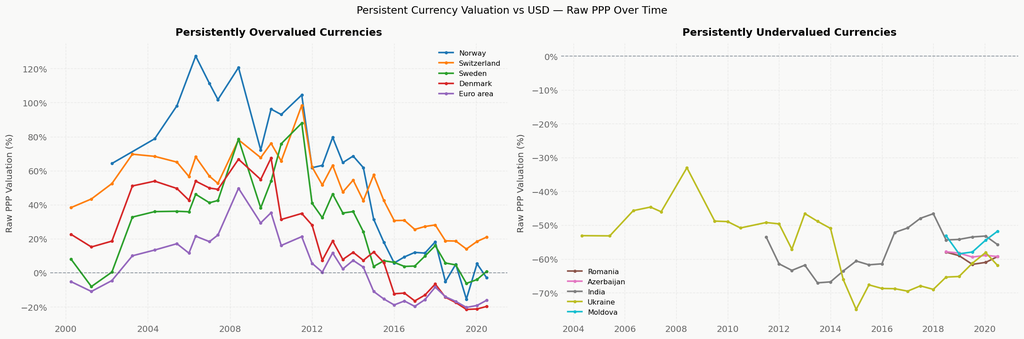

```python
# Find persistently extreme currencies (median absolute valuation across all dates)
median_val = (df.dropna(subset=['USD_raw'])
              .groupby('name')['USD_raw']
              .agg(median_abs=lambda x: x.abs().median(), median=lambda x: x.median())
              .reset_index())

persistent_over  = median_val.nlargest(5, 'median')['name'].tolist()
persistent_under = median_val.nsmallest(5, 'median')['name'].tolist()
highlight = persistent_over + persistent_under

cmap = plt.cm.tab10
color_map = {name: cmap(i) for i, name in enumerate(highlight)}

fig, axes = plt.subplots(1, 2, figsize=(18, 6), facecolor=PALETTE['bg'])
fig.suptitle('Persistent Currency Valuation vs USD — Raw PPP Over Time', fontsize=13)

for ax, names, panel_title in [
    (axes[0], persistent_over,  'Persistently Overvalued Currencies'),
    (axes[1], persistent_under, 'Persistently Undervalued Currencies'),
]:
    for name in names:
        g = df[df['name'] == name].dropna(subset=['USD_raw'])
        ax.plot(g['date'], g['USD_raw'] * 100,
                label=name, linewidth=2, color=color_map[name], marker='o', markersize=3)
    ax.axhline(0, color=PALETTE['secondary'], linewidth=1, linestyle='--', alpha=0.5)
    ax.yaxis.set_major_formatter(mticker.PercentFormatter())
    ax.legend(frameon=False, fontsize=9)
    style_ax(ax, panel_title, '', 'Raw PPP Valuation (%)')

plt.tight_layout()
plt.show()
```

## 5. Price Trend Analysis

For each country, a linear regression of `dollar_price ~ years_since_2000` produces three outputs:

- **Slope** — annual dollar-price change. High slope = rapidly rising cost in USD terms (could reflect inflation, currency appreciation, or both)
- **Intercept** — implied price at year 2000 baseline
- **R²** — how well a linear trend fits the data. High R² means price growth has been steady and predictable; low R² means erratic pricing driven by currency volatility or economic shocks

Interpreting slope requires care: a high slope in a developing country often reflects currency appreciation or hyperinflation rather than rising living standards.

### 5.1 Linear Trend Fitting Per Country

```python
def fit_country(group):
    g = group.dropna(subset=['dollar_price']).copy()
    if len(g) < 4:
        return pd.Series({'slope': np.nan, 'intercept': np.nan, 'r2': np.nan, 'n': len(g)})
    g['years'] = g['date'].dt.year + g['date'].dt.month/12 - 2000
    X = g['years'].values.reshape(-1, 1)
    y = g['dollar_price'].values
    model = LinearRegression().fit(X, y)
    return pd.Series({
        'slope':     model.coef_[0],
        'intercept': model.intercept_,
        'r2':        model.score(X, y),
        'n':         len(g),
    })

country_params = (df.groupby('name')
                   .apply(fit_country)
                   .reset_index()
                   .dropna(subset=['slope']))

# Merge region back in
region_ref = df[['name','region']].drop_duplicates()
country_params = country_params.merge(region_ref, on='name', how='left')

print(f'Countries with valid fits: {len(country_params)}')
print()
print('Summary of slope distribution:')
print(country_params['slope'].describe().round(4).to_string())
print()
print('US trend:')
us_row = country_params[country_params['name'] == 'United States']
print(us_row[['name','slope','intercept','r2']].round(4).to_string(index=False))
```

```
Countries with valid fits: 57

Summary of slope distribution:
count    57.0000
mean      0.1018
std       0.1045
min      -0.0341
25%       0.0411
50%       0.0949
75%       0.1424
max       0.6562

US trend:
         name  slope  intercept     r2
United States 0.1768     2.0952 0.9856
```